# Dose-response analysis with drc — ED50 comparison

2026-05-10

## Background

Portfolio piece — a synthetic recreation of a dose-response analysis I helped run during a colleague’s MSc project. The pipeline takes a plate-level “% of control” response across a range of doses and three stressors — **NaCl** (ionic + osmotic), **PEG-6000** (pure osmotic), and **Zn** (heavy metal) — measured on **Tomato** and **Cress** seedlings, fits a four-parameter log-logistic curve per (species × stressor) using **`drc::drm`**, extracts **ED50** (a.k.a. IC50) with delta-method 95 % CIs, and compares species sensitivity across stressors. The three-stressor design separates ionic vs purely osmotic vs heavy-metal mechanisms.

## Simulated data

```r
source("R/01_simulate.R")
```

```r
dat <- readRDS("data/dose_response.rds")
str(dat)
```

```
## 'data.frame':    252 obs. of  6 variables:
##  $ species : Factor w/ 2 levels "Tomato","Cress": 1 1 1 1 1 1 1 1 1 1 ...
##  $ stressor: Factor w/ 3 levels "NaCl","PEG","Zn": 1 1 1 1 1 1 1 1 1 1 ...
##  $ trial   : Factor w/ 3 levels "1","2","3": 1 1 1 1 1 1 1 1 1 1 ...
##  $ dose    : num  0 0 25 25 50 50 100 100 200 200 ...
##  $ rep     : int  1 2 1 2 1 2 1 2 1 2 ...
##  $ response: num  104.6 102.3 89.8 78.1 77.7 ...
```

## Fitting

```r
source("R/02_fit_drc.R")
```

```r
summary(fits$NaCl)
```

```
##
## Model fitted: Log-logistic (ED50 as parameter) (4 parms)
##
## Parameter estimates:
##
##               Estimate Std. Error t-value   p-value
## slope:Tomato   1.27547    0.14915  8.5516 9.654e-13 ***
## slope:Cress    1.27875    0.22599  5.6583 2.571e-07 ***
## lower:Tomato   3.94751    4.60452  0.8573    0.3940
## lower:Cress    7.42931    8.94473  0.8306    0.4088
## upper:Tomato 103.08978    2.56055 40.2608 < 2.2e-16 ***
## upper:Cress   96.71757    2.57198 37.6043 < 2.2e-16 ***
## ED50:Tomato   98.90957   11.14464  8.8751 2.316e-13 ***
## ED50:Cress   218.64215   40.99303  5.3336 9.583e-07 ***
## ---
## Signif. codes:  0 '***' 0.001 '**' 0.01 '*' 0.05 '.' 0.1 ' ' 1
##
## Residual standard error:
##
##  6.478322 (76 degrees of freedom)
```

## Dose-response curves

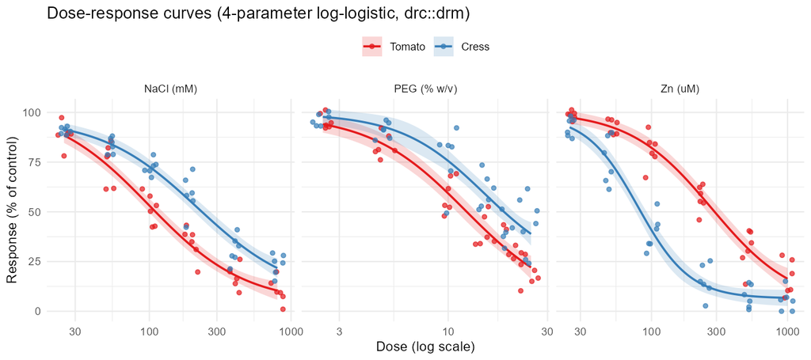

Points are individual replicates; lines are predictions from `LL.4()`; ribbons are 95 % confidence bands.

## SS1 — Dose-response curves with inflection points

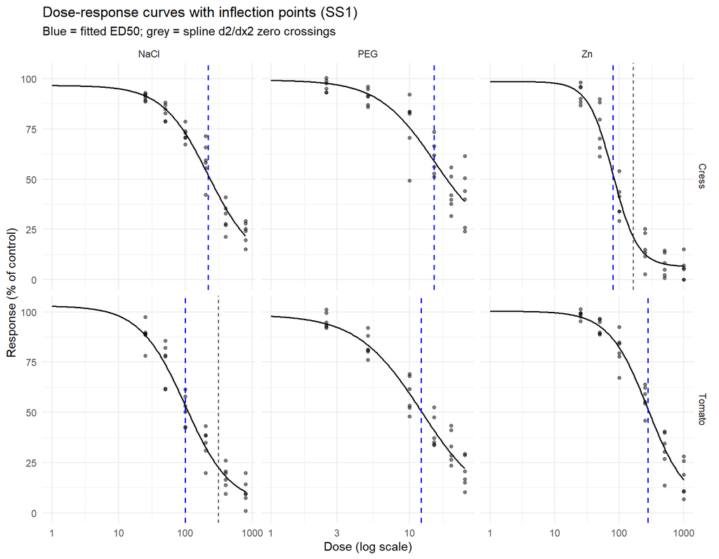

```r
library(ggplot2); library(dplyr)

inflect_points <- function(x, y, n_grid = 400) {
  ord <- order(x); x <- x[ord]; y <- y[ord]
  fit  <- smooth.spline(x, y, spar = 0.55)
  xs   <- seq(min(x), max(x), length.out = n_grid)
  d2   <- predict(fit, xs, deriv = 2)$y
  zc   <- which(diff(sign(d2)) != 0)
  # drop boundary artefacts near the edges of the sampled range
  margin <- 0.08 * (max(x) - min(x))
  xs_zc  <- xs[zc]
  xs_zc[xs_zc > min(x) + margin & xs_zc < max(x) - margin]
}

ss1 <- dat %>%
  group_by(species, stressor, dose) %>%
  summarise(mean_resp = mean(response), .groups = "drop") %>%
  mutate(log_dose = log10(pmax(dose, 1)))

inflect_df <- ss1 %>%
  group_by(species, stressor) %>%
  summarise(infl = list(10 ^ inflect_points(log_dose, mean_resp)),
            .groups = "drop") %>%
  tidyr::unnest(infl)

ed50_lines <- ed50 %>%
  transmute(species, stressor, ed50 = ED50)

# Prediction line on a fine grid extending down to x = 1 so the curve
# is visible across the full log-dose axis (not just the sampled doses).
ss1_pred <- do.call(rbind, lapply(levels(dat$stressor), function(st) {
  m  <- fits[[st]]
  xr <- range(dat$dose[dat$stressor == st & dat$dose > 0])
  xs <- exp(seq(log(1), log(xr[2]), length.out = 250))
  pr <- predict(m, newdata = expand.grid(dose = xs,
                                          species = levels(dat$species)))
  out <- expand.grid(dose = xs, species = levels(dat$species))
  out$mean_resp <- as.numeric(pr)
  out$stressor  <- st
  out
}))
ss1_pred$species  <- factor(ss1_pred$species,  levels = levels(dat$species))
ss1_pred$stressor <- factor(ss1_pred$stressor, levels = levels(dat$stressor))

ggplot(dat[dat$dose > 0, ], aes(dose, response)) +
  geom_point(alpha = 0.5, size = 1.3) +
  geom_line(data = ss1_pred, aes(dose, mean_resp),
            colour = "black", linewidth = 0.6) +
  geom_vline(data = inflect_df, aes(xintercept = infl),
             linetype = "dashed", colour = "grey20", linewidth = 0.4) +
  geom_vline(data = ed50_lines, aes(xintercept = ed50),
             linetype = "dashed", colour = "blue", linewidth = 0.6) +
  facet_grid(species ~ stressor, scales = "free_x") +
  scale_x_log10() +
  labs(x = "Dose (log scale)",
       y = "Response (% of control)",
       title = "Dose-response curves with inflection points (SS1)",
       subtitle = "Blue = fitted ED50; grey = spline d2/dx2 zero crossings") +
  theme_minimal(base_size = 11)
```

```r
ggsave("figures/ss1_inflection.png", width = 9, height = 6, dpi = 150)
```

## SS2 — Trial-to-trial comparison

Three independent trials of the same experiment, overlaid per (species × stressor). Points are trial means, error bars are ± SE across replicates; the vertical green line marks the pooled ED50.

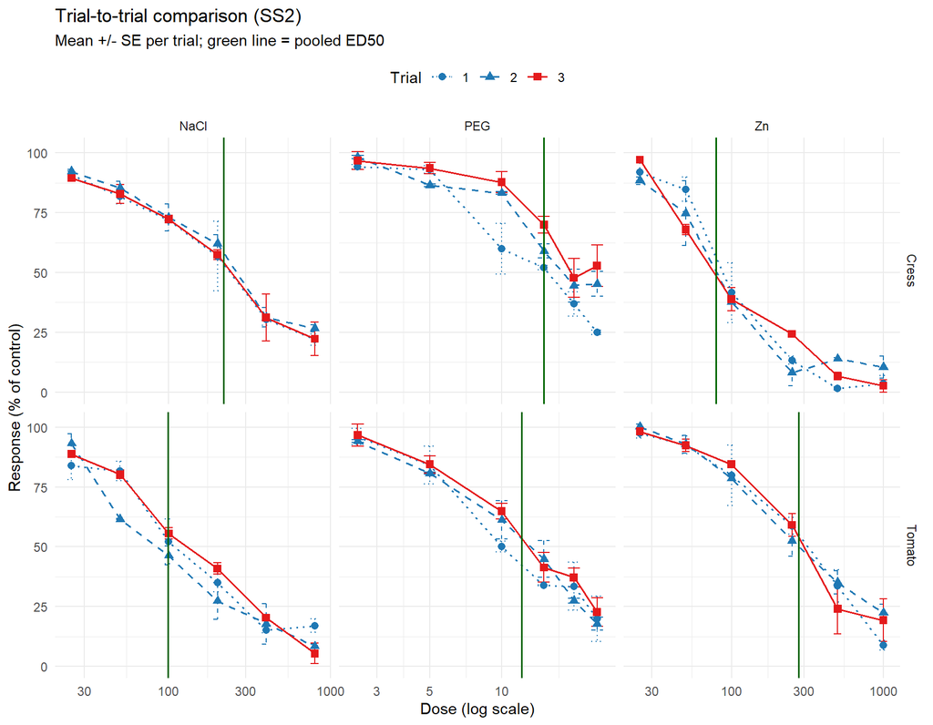

```r
ss2 <- dat %>%
  group_by(species, stressor, trial, dose) %>%
  summarise(mean_resp = mean(response),
            se_resp   = sd(response) / sqrt(n()),
            .groups   = "drop") %>%
  filter(dose > 0)

ggplot(ss2, aes(dose, mean_resp,
                colour   = trial,
                linetype = trial,
                shape    = trial)) +
  geom_errorbar(aes(ymin = mean_resp - se_resp,
                    ymax = mean_resp + se_resp),
                width = 0.05, linewidth = 0.5) +
  geom_line(linewidth = 0.7) +
  geom_point(size = 2.2) +
  geom_vline(data = ed50_lines, aes(xintercept = ed50),
             colour = "darkgreen", linewidth = 0.6, inherit.aes = FALSE) +
  facet_grid(species ~ stressor, scales = "free_x") +
  scale_x_log10() +
  scale_colour_manual(values = c(`1` = "#1F78B4",
                                 `2` = "#1F78B4",
                                 `3` = "#E41A1C")) +
  scale_linetype_manual(values = c(`1` = "dotted",
                                   `2` = "dashed",
                                   `3` = "solid")) +
  scale_shape_manual(values = c(`1` = 16, `2` = 17, `3` = 15)) +
  labs(x = "Dose (log scale)",
       y = "Response (% of control)",
       title = "Trial-to-trial comparison (SS2)",
       subtitle = "Mean +/- SE per trial; green line = pooled ED50",
       colour = "Trial", linetype = "Trial", shape = "Trial") +
  theme_minimal(base_size = 11) +
  theme(legend.position = "top")
```

```r
ggsave("figures/ss2_trials.png", width = 9, height = 6, dpi = 150)
```

## ED50 comparison

```r
knitr::kable(ed50, digits = 2,
             caption = "ED50 with delta-method 95% confidence intervals.")
```

ED50 with delta-method 95% confidence intervals.

| stressor | species | ED50 | SE | Lower95 | Upper95 |
| --- | --- | --- | --- | --- | --- |
| NaCl | Cress | 218.64 | 40.99 | 137.00 | 300.29 |
| NaCl | Tomato | 98.91 | 11.14 | 76.71 | 121.11 |
| PEG | Cress | 14.97 | 4.28 | 6.44 | 23.49 |
| PEG | Tomato | 12.11 | 2.46 | 7.21 | 17.01 |
| Zn | Cress | 79.53 | 4.76 | 70.05 | 89.01 |
| Zn | Tomato | 276.50 | 43.01 | 190.84 | 362.17 |

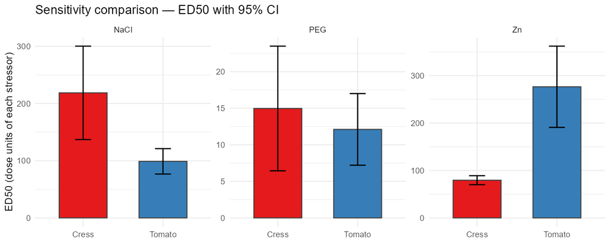

Lower ED50 = the species is *more* sensitive to that stressor.

## Sanity check vs ground truth

Because the data was simulated, we know the true ED50 used by the generator. Compare the fitted ED50 to the truth:

```r
truth <- readRDS("data/truth.rds")
truth_df <- do.call(rbind, lapply(names(truth), function(sp) {
  do.call(rbind, lapply(names(truth[[sp]]), function(st) {
    data.frame(species = sp, stressor = st,
               true_ED50 = unname(truth[[sp]][[st]]["e"]))
  }))
}))
merged <- merge(ed50, truth_df, by = c("species", "stressor"))
merged$rel_error_pct <- 100 * (merged$ED50 - merged$true_ED50) / merged$true_ED50
knitr::kable(merged, digits = 2)
```

| species | stressor | ED50 | SE | Lower95 | Upper95 | true_ED50 | rel_error_pct |
| --- | --- | --- | --- | --- | --- | --- | --- |
| Cress | NaCl | 218.64 | 40.99 | 137.00 | 300.29 | 160 | 36.65 |
| Cress | PEG | 14.97 | 4.28 | 6.44 | 23.49 | 17 | -11.95 |
| Cress | Zn | 79.53 | 4.76 | 70.05 | 89.01 | 90 | -11.63 |
| Tomato | NaCl | 98.91 | 11.14 | 76.71 | 121.11 | 95 | 4.12 |
| Tomato | PEG | 12.11 | 2.46 | 7.21 | 17.01 | 11 | 10.07 |
| Tomato | Zn | 276.50 | 43.01 | 190.84 | 362.17 | 280 | -1.25 |

## Pairwise tests across species (per stressor)

```r
lapply(fits, EDcomp, percVec = c(50, 50), interval = "delta")
```

```
##
## Estimated ratios of effect doses
##
##                    Estimate  Lower  Upper
## Cress/Tomato:50/50   2.2105 1.2475 3.1736
##
## Estimated ratios of effect doses
##
##                    Estimate  Lower  Upper
## Cress/Tomato:50/50   1.2363 0.3725 2.1000
##
## Estimated ratios of effect doses
##
##                    Estimate   Lower   Upper
## Cress/Tomato:50/50  0.28763 0.19214 0.38312
```

```
## $NaCl
##                    Estimate    Lower    Upper
## Cress/Tomato:50/50 2.210526 1.247485 3.173567
##
## $PEG
##                    Estimate     Lower    Upper
## Cress/Tomato:50/50 1.236252 0.3724953 2.100009
##
## $Zn
##                     Estimate     Lower     Upper
## Cress/Tomato:50/50 0.2876295 0.1921439 0.3831151
```

Confidence intervals on the ED50 *ratio* between species, per stressor. A CI not crossing 1 means the two species differ significantly in sensitivity.

## Disclaimer

Numbers are simulated from log-logistic curves with hand-chosen parameters and Gaussian noise. The repo demonstrates the **drc-based fitting workflow**, not a finding about real chemicals or species.